# Card Game Methods

Masoud Jasbi

### Card Types:

There are three animals in the card-game: cat, dog, and elephant. Each card may have one or two of them. I represent the card types in the following way:

Representation

Description

Cards

**X**

Only one animal on the card

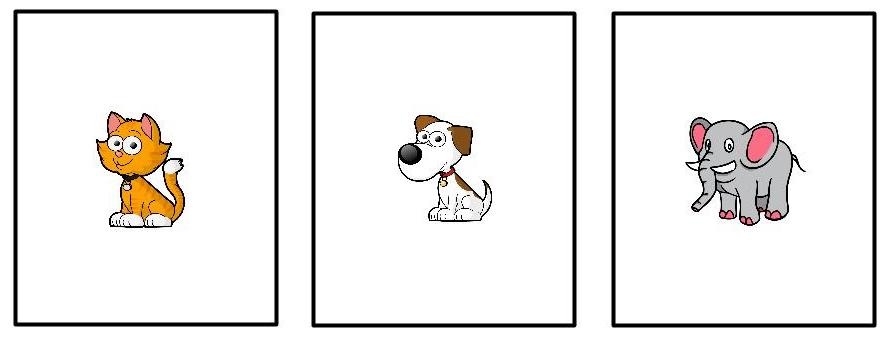

**XY**

Two animals on the card

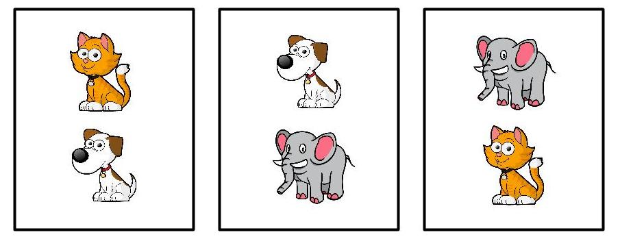

## Guess Types

| Representation | Description |
| --- | --- |
| **Z** | The puppet mentions an animal not on the card |
| **X** | The puppet mentions one of the animals (perhaps the only animal) on the card |
| **XorY** | The puppet mentions both animals on the card and uses the connective “or” |
| **XandY** | The puppet mentions both animals on the card and uses the connective “and” |

## Trial Types

The combination of card types and guess types creats 12 possible trial types and 36 possible trials. We choose 8 trial types out of 12 to balance for the type of card (X vs. XY), the type of guess (with vs. without connective), and types of responses (wrong, right). We represent each trial type using the pattern “CARD-GUESS” with X, Y and Z abstracting over the specific animals:

Representation

Example Card

Example Guess

**XY-XorY**

There is a cat **or** a dog

**XY-XandY**

There is a cat **and** a dog

**XY-X**

There is a cat!

**XY-Z**

There is an elephantl!

**X-XorY**

There is a cat or a dog!

**X-XandY**

There is a cat and a dog!

**X-X**

There is a cat!

**X-Z**

There is a dog!

Below, I create trial type variables that hold lists of the trials in each trial type:

```r
### Two animals, two correct lables with or:
XY.XorY <- list(c("CAT-DOG", "cat or dog"), c("CAT-ELE", "cat or elephant"), c("DOG-ELE", "dog or elephant"))

### Two animals, two correct lables with or:
XY.XandY <- list(c("CAT-DOG", "cat and dog"), c("CAT-ELE", "cat and elephant"), c("DOG-ELE", "dog and elephant"))

### Two animals, one correct lable:
XY.X <- list(c("CAT-DOG", "cat"), c("CAT-DOG", "dog"), c("CAT-ELE", "cat"), c("CAT-ELE", "elephant"), c("DOG-ELE", "dog"), c("DOG-ELE", "elephant"))

### Two animals, one incorrect lable:
XY.Z <- list(c("CAT-DOG", "elephant"), c("CAT-ELE", "dog"), c("DOG-ELE", "cat"))

### One animal, two lables with or, one label correct
X.XorY <- list(c("CAT", "cat or dog"), c("DOG", "cat or dog"), c("CAT", "cat or elephant"), c("ELE", "cat or elephant"), c("DOG", "dog or elephant"), c("ELE", "dog or elephant"))

### One animal, two lables with and, one label correct
X.XandY <- list(c("CAT", "cat and dog"), c("DOG", "cat and dog"), c("CAT", "cat and elephant"), c("ELE", "cat and elephant"), c("DOG", "dog and elephant"), c("ELE", "dog and elephant"))

### one animal, one correct label:
X.X <- list(c("CAT", "cat"), c("DOG", "dog"), c("ELE", "elephant"))

### one animal, one incorrect label:
X.Z <- list(c("CAT", "dog"), c("CAT", "elephant"), c("DOG", "cat"), c("DOG", "elephant"), c("ELE", "cat"), c("ELE", "dog"))
```

### Randomization:

With 8 trial types, it is reasonable to assume that children can sit through two trials per trial type: 16 trials total. Therefore we need to randomly sample 2 trials from the trial types for each participant. Some trial types have 6 trials and some 3. For those with 6 trials I only randomize them. For those with 3, I randomize them twice and bind them to create a list of six trials. This way, each trial type has 6 randomized trials.

```r
XY.XorY.s <- c(sample(XY.XorY), sample(XY.XorY))
XY.XandY.s <- c(sample(XY.XandY), sample(XY.XandY))
XY.X.s <- sample(XY.X)
XY.Z.s <- c(sample(XY.Z), sample(XY.Z))
X.XorY.s <- sample(X.XorY)
X.XandY.s <- sample(X.XandY)
X.X.s <- c(sample(X.X), sample(X.X))
X.Z.s <- sample(X.Z)
```

Now for each trial type, I pick the first two trials for the first participant, the second two for the second, and the third two for the third.

```r
# Taking the first and the second trial of each trial type for participant 1:
part1 <- c(
  sample(c(X.Z.s[1], X.X.s[1], XY.X.s[1])),
  sample(c(XY.XorY.s[1], XY.XandY.s[1], XY.Z.s[1], X.XorY.s[1], X.XandY.s[1])),
  sample(c(XY.XorY.s[2], XY.XandY.s[2], XY.X.s[2], XY.Z.s[2], X.XorY.s[2], X.XandY.s[2], X.X.s[2], X.Z.s[2]))
          )
# Taking the third and the fourth trial of each trial type for participant 2:
part2 <- c(
  sample(c(X.Z.s[3], X.X.s[3], XY.X.s[3])),
  sample(c(XY.XorY.s[3], XY.XandY.s[3], XY.Z.s[3], X.XorY.s[3], X.XandY.s[3])),
  sample(c(XY.X.s[4], XY.XorY.s[4], XY.XandY.s[4], XY.Z.s[4], X.XorY.s[4], X.XandY.s[4], X.X.s[4], X.Z.s[4]))
        )

# Taking the fifth and the sixth trial of each trial type for participant 1:
part3 <- c(
  sample(c(X.Z.s[5], X.X.s[5], XY.X.s[5])),
  sample(c(XY.XorY.s[5], XY.XandY.s[5], XY.Z.s[5], X.XorY.s[5], X.XandY.s[5])),
  sample(c(XY.XorY.s[6], XY.XandY.s[6], XY.X.s[6], XY.Z.s[6], X.XorY.s[6], X.XandY.s[6], X.Z.s[6], X.X.s[6]))
  )
```

The code below saves randomized trials for 3 participants in the expeirment in three separate CSV files.

```r
######### Creating the CSV files:

## File 1:
file1 <- c()
for (i in 1:16) {
   file1 <- rbind(file1, part1[[i]])
}
colnames(file1) <- c("Card", "Guess")
write.csv(file1, file="file1.csv", row.names=FALSE)

## File 2:
file2 <- c()
for (i in 1:16) {
   file2 <- rbind(file2, part2[[i]])
}

colnames(file2) <- c("Card", "Guess")
write.csv(file2, file="file2.csv", row.names=FALSE)

## File 3:
file3 <- c()
for (i in 1:16) {
   file3 <- rbind(file3, part3[[i]])
}

colnames(file3) <- c("Card", "Guess")
write.csv(file3, file="file3.csv", row.names=FALSE)
```

### Procedure:

Three decks of cards are prepared: introduction, instruction, and warm-up+test. The introduction deck includes six cards; one of each card type.

**Introduction**

The experimenter puts the introduction cards on the table and shows them to the puppet and the child. The puppet asks about the name of the animals on the cards. The experimenter waits to see if the child can answer the puppet’s questions. The experimenter can also encourage the child to answer the puppet’s questions.

*Experimenter: Look! My game has a lot of cards!* *Puppet: Ooh look at all these animals! [points to a card] what is this one? [waits for answer, points to another card] What is on this one? etc.*

When it is clear that the child knows the animals well the experimeter proceeds to the instruction deck.

**Instruction**

Then the experimenter explains the game to the puppet. Picks up the instruction deck. The instruction deck is always arranged as: CAT > ELEPHANT > CAT-DOG. The puppet guesses are: dog > elephant > cat. The experimenter responds to geusses with: “Sorry. That’s not right” > “Yes! That’s right” > “That’s a little bit right!”. After each feedback, he also explains to the child how to give feedback to the puppet.

*Now! I’m going to put the cards like this [puts the warm-up deck on the table face down]. I’m going to pick this card on the top. Can you guess what animal is on this one? What is on this card? [puppet guesses] Yes! That’s right! When [puppet name] is right, you can tell her: Yes! you are right.*

**Warm-up + Test**

The warm-up+test deck is arranged according to the order of the trials in the participant csv file. When the instruction deck is done, the puppet asks to play with the child. The experimenter explains to the child:

*Here are some more cards [uses the warm-up+test deck]. Now you pick a card and Jazzy is going to guess what is on the card. If Jazzy is right, tell her “you are right”! If she is a little bit right, tell her “you are a little bit right”, if she is wrong, tell her “sorry. that’s not right”*

The first three trials of this deck are arranged as warm-up. They have the trial types in the instruction set but the order and animals are randomized. The warm up trials let us know how comfortable the child is with giving feedback. The next 13 trials are test trials. They include all the conjunction and disjunction trials.